# 1 Aufbereitung des Diversity Profiles

### 1.8.2 Plot Raw Data

**Visualize Raw Data**

#### 1.8.2.1 SSS

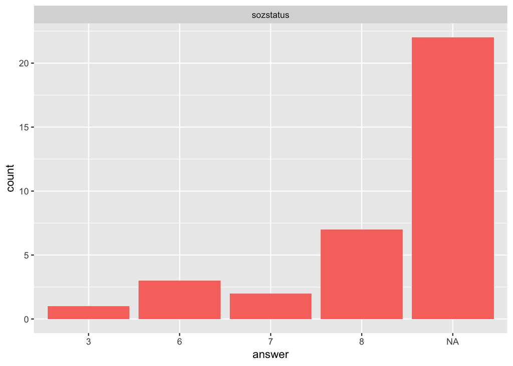

```r
raw8 %>% frqplot_mc("sozstatus")
```

#### 1.8.2.2 Einkommen

Außerdem gibt es Informationen zum Einkommen `einkgr`und `neteink`.

```
  Note: Neteink ist momentan nicht im Datensatz vorhanden
```

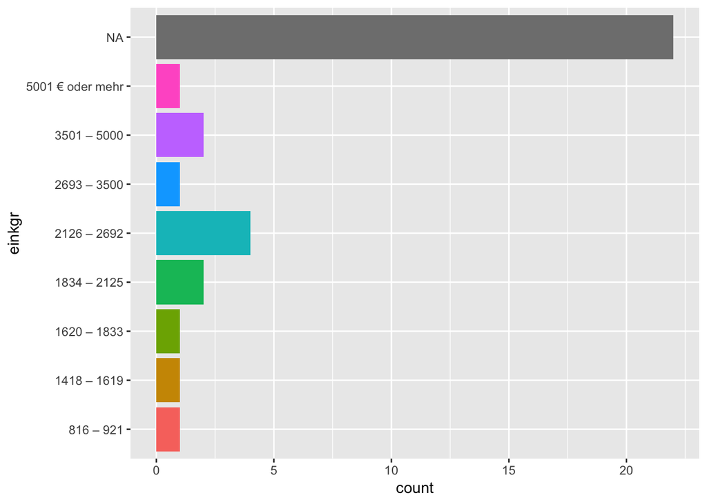

```r
raw8 %>% select(einkgr) %>%
      ggplot(aes(x = einkgr, fill = einkgr)) +
      geom_bar() +
      coord_flip() +
      theme(legend.position = "none")
```

```r
# raw8 %>% select(neteink) %>%
#       ggplot(aes(x = einkgr, fill = einkgr)) +
#       geom_bar() +
#       coord_flip() +
#       theme(legend.position = "none")
```

#### 1.8.2.5 Lebenssituation

Informationen zur Lebenssituation `lebsit`

```r
raw8 %>% frq_mc("lebsit")
```

| var | Ja | Nicht Gewählt | NA_ |
| --- | --- | --- | --- |
| lebsit_SQ002 | 0.06 | 0.40 | 0.54 |
| lebsit_SQ003 | 0.03 | 0.43 | 0.54 |
| lebsit_SQ004 | 0.03 | 0.43 | 0.54 |
| lebsit_SQ005 | 0.06 | 0.40 | 0.54 |
| lebsit_SQ006 | 0.06 | 0.40 | 0.54 |
| lebsit_SQ007 | 0.06 | 0.40 | 0.54 |
| lebsit_SQ008 | 0.03 | 0.43 | 0.54 |

**Generate New Variable**

#### 1.8.3.1 SSS

```r
levels(raw8$aktberuf)
```

```
##  [1] "Auszubildende_r / Anwärter_in"
##  [2] "ungelernte_r Arbeiter_in"
##  [3] "angelernte_r Arbeiter_in"
##  [4] "gelernte_r oder Facharbeiter_in"
##  [5] "Meister_in"
##  [6] "Beamte_r im einfachen Dienst"
##  [7] "Beamte_r im mittleren Dienst"
##  [8] "Beamte_r im gehobenen Dienst"
##  [9] "Beamte_r im höheren Dienst (z.B. Staatssekretär_in); Richter_in"
## [10] "Angestellte_r mit ausführender Tätigkeit (z.B. Bürobot_in, Postverteiler_in)"
## [11] "Angestellte_r mit qualifizierter Tätigkeit (z.B. Sachbearbeiter_in, Buchhalter_in)"
## [12] "Angestellte_r mit hochqualifizierter Tätigkeit (wissenschaftliche_r Mitarbeiter_in, Abteilungsleiter_in)"
## [13] "Angestellte_r mit umfassender Führungstätigkeit (z.B. Behördenleiter_in)"
```

```r
raw9 <- raw8 %>%
      mutate(sss = as.numeric(as.character(sozstatus)),
             # hier kommt noch neteink hin
             isei = case_when(# recode aktberuf
                   grepl(levels(raw8$aktberuf)[1], aktberuf) |
                   grepl(levels(raw8$aktberuf)[2], aktberuf) ~ "SES1 [1,3]",
                   grepl(levels(raw8$aktberuf)[3], aktberuf) ~ "SES2 [1,8]",
                   # grepl(levels(raw8$aktberuf)[4], aktberuf) ~ "SES3 [2,0]", fehlt momentan noch
                   grepl(levels(raw8$aktberuf)[4], aktberuf) ~ "SES4 [2,1]",
                   grepl(levels(raw8$aktberuf)[5], aktberuf) ~ "SES5 [2,4]",
                   grepl(levels(raw8$aktberuf)[6], aktberuf) ~ "SES6 [2,9]",
                   grepl(levels(raw8$aktberuf)[7], aktberuf) ~ "SES7 [4,1]",
                   grepl(levels(raw8$aktberuf)[8], aktberuf) ~ "SES8 [5,2]",
                   grepl(levels(raw8$aktberuf)[9], aktberuf) ~ "SES9 [6,4]",
                   grepl(levels(raw8$aktberuf)[10], aktberuf) ~ "SES10 [2,4]",
                   grepl(levels(raw8$aktberuf)[11], aktberuf) ~ "SES11 [3,6]",
                   grepl(levels(raw8$aktberuf)[12], aktberuf) ~ "SES12 [6,2]",
                   grepl(levels(raw8$aktberuf)[13], aktberuf) ~ "SES13 [4,7]",
                   TRUE ~ NA_character_),
             isei_score = case_when(# recode aktberuf
                   grepl(levels(raw8$aktberuf)[1], aktberuf) |
                   grepl(levels(raw8$aktberuf)[2], aktberuf) ~ 1.3,
                   grepl(levels(raw8$aktberuf)[3], aktberuf) ~ 1.8,
                   # grepl(levels(raw8$aktberuf)[4], aktberuf) ~ 2.0, fehlt momentan noch
                   grepl(levels(raw8$aktberuf)[4], aktberuf) ~ 2.1,
                   grepl(levels(raw8$aktberuf)[5], aktberuf) ~ 2.4,
                   grepl(levels(raw8$aktberuf)[6], aktberuf) ~ 2.9,
                   grepl(levels(raw8$aktberuf)[7], aktberuf) ~ 4.1,
                   grepl(levels(raw8$aktberuf)[8], aktberuf) ~ 5.2,
                   grepl(levels(raw8$aktberuf)[9], aktberuf) ~ 6.4,
                   grepl(levels(raw8$aktberuf)[10], aktberuf) ~ 2.4,
                   grepl(levels(raw8$aktberuf)[11], aktberuf) ~ 3.6,
                   grepl(levels(raw8$aktberuf)[12], aktberuf) ~ 6.2,
                   grepl(levels(raw8$aktberuf)[13], aktberuf) ~ 4.7,
                   TRUE ~ NA_real_),
             eink_score = case_when(# recode aktberuf
                   grepl(levels(raw8$einkgr)[1], einkgr) ~ 1.0,
                   grepl(levels(raw8$einkgr)[2], einkgr) ~ 1.5,
                   grepl(levels(raw8$einkgr)[3], einkgr) ~ 2.0,
                   grepl(levels(raw8$einkgr)[4], einkgr) ~ 2.5,
                   grepl(levels(raw8$einkgr)[5], einkgr) ~ 3.0,
                   grepl(levels(raw8$einkgr)[6], einkgr) ~ 3.5,
                   grepl(levels(raw8$einkgr)[7], einkgr) ~ 4.0,
                   grepl(levels(raw8$einkgr)[8], einkgr) ~ 4.5,
                   grepl(levels(raw8$einkgr)[9], einkgr) ~ 5.5,
                   grepl(levels(raw8$einkgr)[10], einkgr) ~ 6.0,
                   grepl(levels(raw8$einkgr)[11], einkgr) ~ 6.5,
                   grepl(levels(raw8$einkgr)[12], einkgr) |
                   grepl(levels(raw8$einkgr)[13], einkgr) |
                   grepl(levels(raw8$einkgr)[14], einkgr) ~ 7.0,
                   TRUE ~ NA_real_),
             # variable für care / lebenssituation erstellen
             care = case_when(
                   lebsit_SQ002 == "Ja" |
                   lebsit_SQ005 == "Ja" ~ "ohne care",
                   lebsit_SQ003 == "Ja" |
                   lebsit_SQ004 == "Ja" |
                   lebsit_SQ008 == "Ja" ~ "hoher carebedarf",
                   lebsit_SQ006 == "Ja" |
                   lebsit_SQ007 == "Ja" ~ "low care bedarf",
                   TRUE ~ NA_character_),
             care = factor(care, c("ohne care", "hoher carebedarf", "low care bedarf")),
             # casmin für bildung
             casmin = case_when(
                   grepl(levels(raw8$bildab)[1], bildab) ~ "SES1a [1.0]",
                   grepl(levels(raw8$bildab)[2], bildab) ~ "SES1b [1.7]",
                   grepl(levels(raw8$bildab)[3], bildab) ~ "SES1c [3.0]",
                   grepl(levels(raw8$bildab)[4], bildab) ~ "SES2b [2.8]",
                   grepl(levels(raw8$bildab)[5], bildab) ~ "SES2a [3.6]",
                   grepl(levels(raw8$bildab)[6], bildab) ~ "SES2cgen [3.7]",
                   grepl(levels(raw8$bildab)[7], bildab) ~ "SES2cvoc [4.8]",
                   grepl(levels(raw8$bildab)[8], bildab) ~ "SES3a [6.1]",
                   grepl(levels(raw8$bildab)[9], bildab) |
                   grepl(levels(raw8$bildab)[10], bildab) ~ "SES3b [7.0]",
                   TRUE ~ NA_character_),
             casmin_score = case_when(
                   grepl(levels(raw8$bildab)[1], bildab) ~ 1.0,
                   grepl(levels(raw8$bildab)[2], bildab) ~ 1.7,
                   grepl(levels(raw8$bildab)[3], bildab) ~ 3.0,
                   grepl(levels(raw8$bildab)[4], bildab) ~ 2.8,
                   grepl(levels(raw8$bildab)[5], bildab) ~ 3.6,
                   grepl(levels(raw8$bildab)[6], bildab) ~ 3.7,
                   grepl(levels(raw8$bildab)[7], bildab) ~ 4.8,
                   grepl(levels(raw8$bildab)[8], bildab) ~ 6.1,
                   grepl(levels(raw8$bildab)[9], bildab) |
                   grepl(levels(raw8$bildab)[10], bildab) ~ 7.0,
                   TRUE ~ NA_real_),
             ses_score = eink_score + isei_score + casmin_score,
             ses = case_when(ses_score <= 1 & ses_score <= 7.9 ~ "niedrig",
                             ses_score <= 8 & ses_score <= 13.8 ~ "mittel",
                             ses_score <= 13.9 & ses_score <= 21 ~ "hoch")
             )
```

lasst uns die neuen Variablen ansehen

```r
raw9 %>% select(
      isei, isei_score, # Beruf
      casmin, casmin_score,       # Bildung
      eink_score,      # einkommen
      care,       # lebessituation
      sozstatus, sss,       # Sozialer Status
      ses_score, ses       # Sozioökonomischer Status
      ) %>%
      skim()
```

| variable | type | stat | level | value | formatted |
| --- | --- | --- | --- | --- | --- |
| isei | character | missing | .all | 33.000000 | 33 |
| isei | character | complete | .all | 2.000000 | 2 |
| isei | character | n | .all | 35.000000 | 35 |
| isei | character | min | .all | 10.000000 | 10 |
| isei | character | max | .all | 10.000000 | 10 |
| isei | character | empty | .all | 0.000000 | 0 |
| isei | character | n_unique | .all | 2.000000 | 2 |
| isei_score | numeric | missing | .all | 33.000000 | 33 |
| isei_score | numeric | complete | .all | 2.000000 | 2 |
| isei_score | numeric | n | .all | 35.000000 | 35 |
| isei_score | numeric | mean | .all | 3.250000 | 3.25 |
| isei_score | numeric | sd | .all | 1.202082 | 1.2 |
| isei_score | numeric | p0 | .all | 2.400000 | 2.4 |
| isei_score | numeric | p25 | .all | 2.825000 | 2.82 |
| isei_score | numeric | p50 | .all | 3.250000 | 3.25 |
| isei_score | numeric | p75 | .all | 3.675000 | 3.67 |
| isei_score | numeric | p100 | .all | 4.100000 | 4.1 |
| isei_score | numeric | hist | .all | NA | ▇▁▁▁▁▁▁▇ |
| casmin | character | missing | .all | 22.000000 | 22 |
| casmin | character | complete | .all | 13.000000 | 13 |
| casmin | character | n | .all | 35.000000 | 35 |
| casmin | character | min | .all | 11.000000 | 11 |
| casmin | character | max | .all | 14.000000 | 14 |
| casmin | character | empty | .all | 0.000000 | 0 |
| casmin | character | n_unique | .all | 5.000000 | 5 |
| casmin_score | numeric | missing | .all | 22.000000 | 22 |
| casmin_score | numeric | complete | .all | 13.000000 | 13 |
| casmin_score | numeric | n | .all | 35.000000 | 35 |
| casmin_score | numeric | mean | .all | 5.846154 | 5.85 |
| casmin_score | numeric | sd | .all | 1.413397 | 1.41 |

[output cut: 71 more lines]

# 2 Save data

```r
data_processed <- raw6
saveRDS(data_processed, file = paste(outpath, "data_processed.rds", sep = "/"))
```

# 3 Cut Outs

Gender: if you want a tibble as output

other wy of calculating frequency tables

and an even shorter way

filter nachdem tidy_mc benutzt wurde

another way to recode factors

another grepl anwendung

```r
rassdisk_subset <- raw1[,grepl(c("diskallg"), attributes(raw1)$names)]
```

cowplot

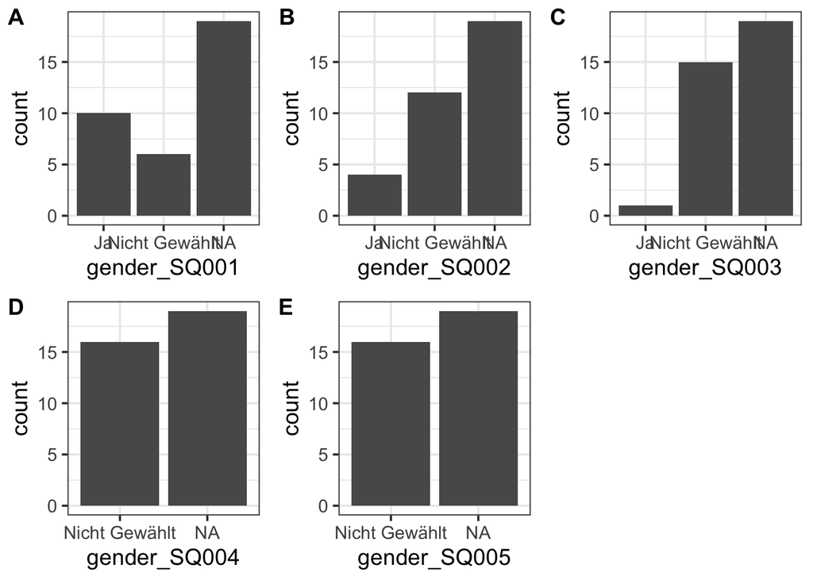

```r
cowplot::plot_grid(plotlist = barplot_mc(raw1, "gender"),
          labels = "AUTO",
          align = "hv")
```

# 4 help

- purrr: https://stackoverflow.com/questions/49989741/error-using-dplyrcount-within-purrrmap
- purrr: https://stackoverflow.com/questions/43013175/function-to-generate-multiple-htmltables-using-purrrmap
- purrr und plots: https://aosmith.rbind.io/2018/01/31/added-variable-plots/
- writing functions in dplyr: https://www.r-bloggers.com/programming-with-dplyr-by-using-dplyr/
- programming in dplyr: https://dplyr.tidyverse.org/articles/programming.html

# 5 template structure

## 5.1 Dimension_XXX

zuerst sehen wir uns die vorhandenen Roh-Daten an, die etwas mit der Dimension rassistische Diskriminierung des Diversity Profils zu tun haben

### 5.1.1 Info Raw Data

**Describe Raw Data**

### 5.1.2 Plot Raw Data

**Visualize Raw Data**

### 5.1.3 Variable_XXX

**Generate New Variable**